# ISA/STA 365 Exam 2 Output Packet

## Email Marketing:Experiment 1

A company wants to compare 4 email subject lines on open rate.

Treatments (subject lines):

A: “Quick question about your account…”

B: “Your January update is here”

C: “A tip to save you time today”

D: “New features you’ll like”

The company knows that its 4 different customer segments behave in different ways but they wish to find the treatment that works regardless of the segment.

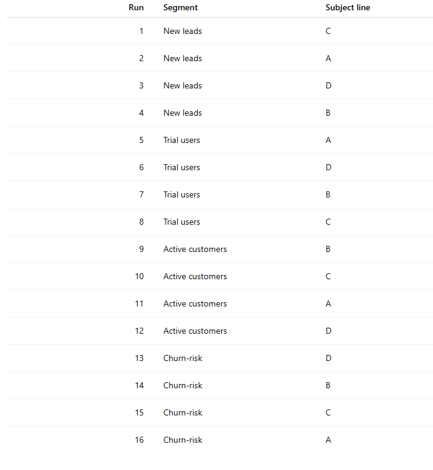

## Email Marketing: Experiment 2

A company wants to compare 4 email subject lines on open rate.

Treatments (subject lines):

A: “Quick question about your account…”

B: “Your January update is here”

C: “A tip to save you time today”

D: “New features you’ll like”

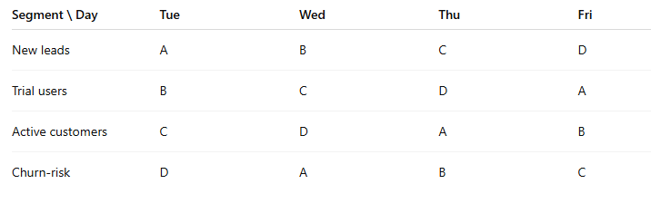

## Esty Testing

Etsy A/B/C tested at least 2 variations of their navigation, placing traditional category links (A version) against fly-out categories and breadcrumbs. The B variation had both the fly-out categories and breadcrumbs. The C variation had just the bread crumbs. In this test, they measured the click through rate on the “Add to Basket” button. Below is the `head()` of the data.

[figure not shown]

[figure not shown]

[figure not shown]

```
##   user_id variant clicked
## 1 U004497       B       0
## 2 U006653       B       0
## 3 U007402       B       0
## 4 U011386       C       0
## 5 U000557       A       1
## 6 U009756       C       0
```

### Analysis

```r
mod<-aov(clicked~variant, data=df)
summary(mod)
```

```
##                Df Sum Sq Mean Sq F value   Pr(>F)
## variant         2    2.5  1.2461   11.58 9.48e-06 ***
## Residuals   11997 1291.2  0.1076
## ---
## Signif. codes:  0 '***' 0.001 '**' 0.01 '*' 0.05 '.' 0.1 ' ' 1
```

```r
test<-chisq.test(table(df$variant, df$clicked), correct = FALSE)
test
```

```
##
##  Pearson's Chi-squared test
##
## data:  table(df$variant, df$clicked)
## X-squared = 23.117, df = 2, p-value = 9.556e-06
```

### Follow Up Analysis

```r
TukeyHSD(mod)
```

```
##   Tukey multiple comparisons of means
##     95% family-wise confidence level
##
## Fit: aov(formula = clicked ~ variant, data = df)
##
## $variant
##         diff          lwr          upr     p adj
## B-A  0.01200 -0.005195014  0.029195014 0.2306023
## C-A -0.02275 -0.039945014 -0.005554986 0.0054841
## C-B -0.03475 -0.051945014 -0.017554986 0.0000065
```

```r
test$residuals
```

```
##
##              0          1
##   A -0.2419896  0.6464156
##   B -1.0523736  2.8111561
##   C  1.2943632 -3.4575717
```

## Subgroup Analysis

A streaming company runs an A/B test of a new “Recommended for You” module on the home page.

Treatment A: current module

Treatment B: new module

Outcome: converted = 1 if the user starts a paid trial within 24 hours, else 0

They also collected other variables including: device (Mobile/Desktop), prior_purchases (count), tenure_days, and email_member (0/1).

### Analysis

| user_id | treatment | device | prior_purchases | tenure_days | email_member | high_intent | converted |
| --- | --- | --- | --- | --- | --- | --- | --- |
| U009238 | B | Mobile | 0 | 14 | 0 | 0 | 0 |
| U005887 | A | Mobile | 1 | 11 | 0 | 0 | 0 |
| U007292 | B | Desktop | 1 | 37 | 1 | 0 | 0 |
| U004500 | A | Mobile | 2 | 31 | 1 | 0 | 0 |
| U006728 | A | Desktop | 1 | 15 | 1 | 0 | 0 |
| U010333 | A | Mobile | 1 | 12 | 1 | 0 | 0 |

### Test 1: Prior Purchasers

```r
prior<-df %>% filter(prior_purchases==1)
prior %>% group_by(treatment, converted) %>% summarize(n=n()) %>% mutate(prop=n/sum(n))
```

```
## # A tibble: 4 × 4
## # Groups:   treatment [2]
##   treatment converted     n   prop
##   <chr>         <int> <int>  <dbl>
## 1 A                 0  1917 0.918
## 2 A                 1   172 0.0823
## 3 B                 0  1950 0.922
## 4 B                 1   166 0.0784
```

```r
prop.test(x=c(172, 166), n=c(1917+172, 1950+166))
```

```
##
##  2-sample test for equality of proportions with continuity correction
##
## data:  c(172, 166) out of c(1917 + 172, 1950 + 166)
## X-squared = 0.16541, df = 1, p-value = 0.6842
## alternative hypothesis: two.sided
## 95 percent confidence interval:
##  -0.01302693  0.02079921
## sample estimates:
##     prop 1     prop 2
## 0.08233605 0.07844991
```

### Test 2: Mobile Users

```r
device<-df %>% filter(device=="Mobile")
device %>% group_by(treatment, converted) %>% summarize(n=n()) %>% mutate(prop=n/sum(n))
```

```
## # A tibble: 4 × 4
## # Groups:   treatment [2]
##   treatment converted     n   prop
##   <chr>         <int> <int>  <dbl>
## 1 A                 0  3571 0.927
## 2 A                 1   281 0.0729
## 3 B                 0  3568 0.924
## 4 B                 1   293 0.0759
```

```r
prop.test(x=c(281, 293), n=c(3571+281, 3568+293))
```

```
##
##  2-sample test for equality of proportions with continuity correction
##
## data:  c(281, 293) out of c(3571 + 281, 3568 + 293)
## X-squared = 0.20086, df = 1, p-value = 0.654
## alternative hypothesis: two.sided
## 95 percent confidence interval:
##  -0.014911175  0.009035258
## sample estimates:
##     prop 1     prop 2
## 0.07294912 0.07588708
```

### Test 3: Email Members

```r
df %>%  group_by(email_member, converted) %>% summarize(n=n()) %>% mutate(prop=n/sum(n))
```

```
## # A tibble: 4 × 4
## # Groups:   email_member [2]
##   email_member converted     n   prop
##          <int>     <int> <int>  <dbl>
## 1            0         0  7226 0.923
## 2            0         1   606 0.0774
## 3            1         0  3758 0.902
## 4            1         1   410 0.0984
```

```r
prop.test(x=c(606, 410), n=c(7226+606, 3758+410))
```

```
##
##  2-sample test for equality of proportions with continuity correction
##
## data:  c(606, 410) out of c(7226 + 606, 3758 + 410)
## X-squared = 15.201, df = 1, p-value = 9.666e-05
## alternative hypothesis: two.sided
## 95 percent confidence interval:
##  -0.03198292 -0.01000438
## sample estimates:
##     prop 1     prop 2
## 0.07737487 0.09836852
```

## Poshmark Testing

Poshmark tested three different footer designs that directed users to a customer help center page. One version was a long-form footer that included multiple paragraphs describing the company’s mission, background, and community values, while the other versions were shorter and more utilitarian.

User sales were measured for each footer variation and compared to determine which design led to the strongest overall performance.

### Analysis

```r
mod<-aov(Spend~Footer, data=df_long)
summary(mod)
```

```
##              Df Sum Sq Mean Sq F value Pr(>F)
## Footer        2    507  253.60    3.91 0.0205 *
## Residuals   717  46500   64.85
## ---
## Signif. codes:  0 '***' 0.001 '**' 0.01 '*' 0.05 '.' 0.1 ' ' 1
```

```r
mod<-aov(Spend~Region, data=df_long)
summary(mod)
```

```
##              Df Sum Sq Mean Sq F value Pr(>F)
## Region        1     30   30.35   0.464  0.496
## Residuals   718  46977   65.43
```

```r
mod<-aov(Spend~Footer+Region, data=df_long)
summary(mod)
```

```
##              Df Sum Sq Mean Sq F value Pr(>F)
## Footer        2    507  253.60   3.908 0.0205 *
## Region        1     30   30.35   0.468 0.4943
## Residuals   716  46470   64.90
## ---
## Signif. codes:  0 '***' 0.001 '**' 0.01 '*' 0.05 '.' 0.1 ' ' 1
```

```r
mod<-aov(Spend~Footer+Region, data=df_long)
summary(mod)
```

[output not shown]

### Assumptions for ANOVA

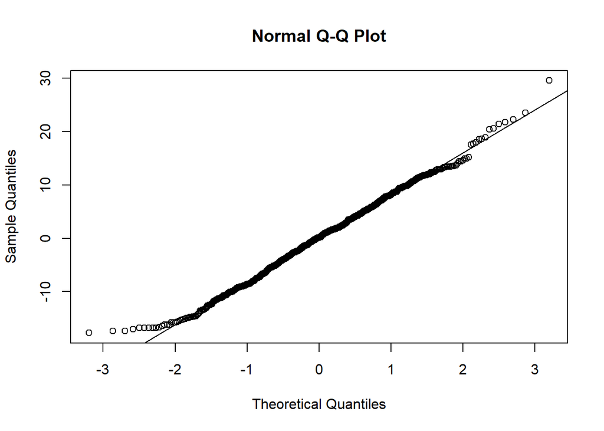

### Tukey’s Test

```
##          diff        lwr      upr      p adj
## B-A 0.5979167 -1.1238928 2.319726 0.69348414
## C-A 2.0024583  0.2806489 3.724268 0.01773421
## C-B 1.4045417 -0.3172678 3.126351 0.13491986
```

## Online Retailer

An online retailer wants to understand how pricing strategy and shipping offer affect average order value (AOV). They choose to run an experiment with two factors, Price and Shipping and they choose a high and a low level for each factor. The full experimental data is displayed below.

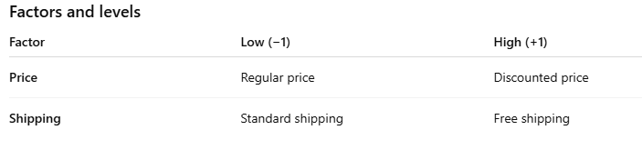

| price_level | shipping_level | average_order_value |
| --- | --- | --- |
| -1 | -1 | 40.83 |
| -1 | 1 | 46.99 |
| 1 | -1 | 49.57 |
| 1 | 1 | 59.99 |
| -1 | -1 | 41.84 |
| -1 | 1 | 48.30 |
| 1 | -1 | 44.15 |
| 1 | 1 | 62.14 |
| -1 | -1 | 45.53 |
| -1 | 1 | 43.27 |
| 1 | -1 | 47.64 |
| 1 | 1 | 62.81 |

### Analysis

```r
reg<-lm(average_order_value~(price_level+shipping_level)^2, data=df)
summary(reg)
```

```
##
## Call:
## lm(formula = average_order_value ~ (price_level + shipping_level)^2,
##     data = df)
##
## Residuals:
##     Min      1Q  Median      3Q     Max
## -2.9700 -1.7183  0.5067  1.4008  2.7967
##
## Coefficients:
##                            Estimate Std. Error t value Pr(>|t|)
## (Intercept)                 49.4217     0.6869  71.949 1.55e-12 ***
## price_level                  4.9617     0.6869   7.223 9.04e-05 ***
## shipping_level               4.4950     0.6869   6.544  0.00018 ***
## price_level:shipping_level   2.7683     0.6869   4.030  0.00379 **
## ---
## Signif. codes:  0 '***' 0.001 '**' 0.01 '*' 0.05 '.' 0.1 ' ' 1
##
## Residual standard error: 2.379 on 8 degrees of freedom
## Multiple R-squared:  0.9329, Adjusted R-squared:  0.9077
## F-statistic: 37.08 on 3 and 8 DF,  p-value: 4.85e-05
```

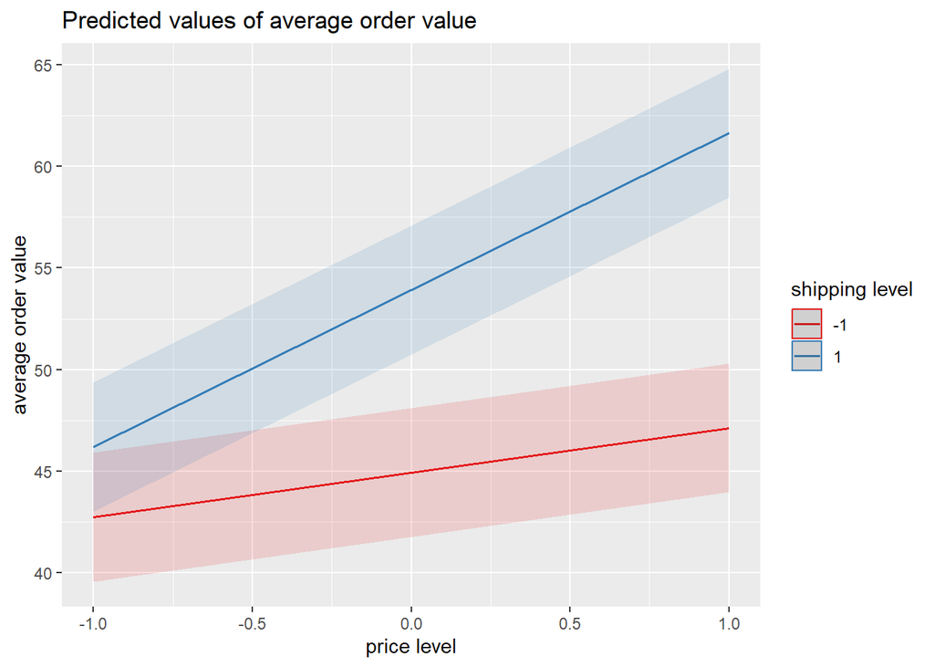

```r
library(sjPlot)
plot_model(reg, type="int")
```